# Náhodná premenná a jej pravdepodobnostné rozdelenie

Dominika Sónak Ballová

2.10.2023

# 1 Ako to funguje v R

Použijeme názov rozdelenia, parametre a vhodnú alternatívu: p=probability, q=quantile, d=density, r=random

binom, exp, hyper, norm, pois, unif

# 2 Diskrétna náhodná premenná

Uveďte konkrétne príklady diskrétnej náhodnej premennej. (nie vymenovať typy)

## 2.1 Binomické rozdelenie

Predpokladajme, že na teste je dvanásť otázok s možnosťami výberu odpovede. Každá otázka má päť možných odpovedí a len jedna z nich je správna. Nájdite rozdelenie pravdepodobnosti NP X, ktorá je počet správne zodpovedaných otázok na teste, vypočítajte strednú hodnotu a disperziu, pravdepodobnosť, že študent zodpovie štyri otázky správne, štyri alebo menej otázok správne, ak študent odpovedá na každú otázku náhodne. Na úspešné ukončenie predmetu je potrebné získať aspoň 7 bodov. Aká je pravdepodobnosť, že študent úspešne absolvuje predmet?

```r
X <- 0:12
p <- 0.2
n <- 12
(P <- dbinom(X,n,p) )
```

```
##  [1] 6.871948e-02 2.061584e-01 2.834678e-01 2.362232e-01 1.328756e-01
##  [6] 5.315022e-02 1.550215e-02 3.321889e-03 5.190451e-04 5.767168e-05
## [11] 4.325376e-06 1.966080e-07 4.096000e-09
```

```r
max(P*100)
```

```
## [1] 28.34678
```

```r
G <- pbinom(X,n,p)
G
```

```
##  [1] 0.06871948 0.27487791 0.55834575 0.79456895 0.92744450 0.98059472
##  [7] 0.99609687 0.99941876 0.99993780 0.99999547 0.99999980 1.00000000
## [13] 1.00000000
```

```r
E<-sum(P*X)
E
```

```
## [1] 2.4
```

```r
D<- sum(P*(X-E)^2)
c(E,D)
```

```
## [1] 2.40 1.92
```

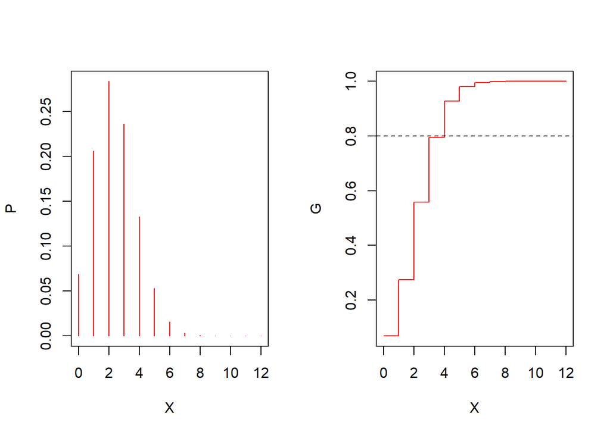

```r
par(mfrow=c(1,2)) # rozdelí vykreslovanie grafov na 1x2
plot(X, P, type="h", col="red")
plot(X, G, type="s", col="red"); abline(h=0.8, lty=2)
```

```r
dbinom(4, size=12, prob=0.2)
```

```
## [1] 0.1328756
```

```r
dbinom(0, size=12, prob=0.2) +
  + dbinom(1, size=12, prob=0.2) +
  + dbinom(2, size=12, prob=0.2) +
  + dbinom(3, size=12, prob=0.2) +
  + dbinom(4, size=12, prob=0.2)
```

```
## [1] 0.9274445
```

```r
p<-pbinom(4, size=12, prob=0.2)
1-p # aspon 5
```

```
## [1] 0.0725555
```

```r
1-pbinom(6,12,0.2)
```

```
## [1] 0.003903132
```

```r
pbinom(6,12,0.2,lower=F)
```

```
## [1] 0.003903132
```

```r
?qbinom
```

```
## starting httpd help server ... done
```

## 2.2 Poissonovo rozdelenie

Cez most prechádza v priemere dvanásť vozidiel za minútu. Určte pravdepodobnosť, že v určitej minúte prejde cez most sedemnásť alebo viac vozidiel.

```r
1- ppois(16,12)
```

```
## [1] 0.101291
```

# 3 Spojité náhodné premenné

Uveďte konkrétne príklady spojitej náhodnej premennej. (nie vymenovať typy)

## 3.1 Rovnomerné rozdelenie

dunif, punif, qunif, runif

Predpokladajme, že doba v sekundách, po ktorú sa osemtýždňové dieťa smeje sa riadi rovnomerným rozdelením od 0 do 23 sekúnd, vrátane hraničných hodnôt. Vypočítajte pravdepodobnosť, že a) rodič stihne dieťa odfotiť, keď potrebuje na nastavenie fotenia v mobile čas 5 sekúnd b) dieťa sa usmeje po dobu menej ako 10 sekúnd c) vykreslite hustotu a distribučnú funkciu

## 3.2 Normálne rozdelenie

Predpokladajme, že počet bodov získaných na prijímacej skúške na vysokej škole má normálne rozdelenie. Okrem toho vieme, že očakávaná hodnota počtu bodov je 72 a smerodajná odchýlka je 15,2. Koľko percent študentov, získalo 84 alebo viac bodov?

```r
pnorm(84, mean=72, sd=15.2, lower.tail=FALSE)
```

```
## [1] 0.2149176
```

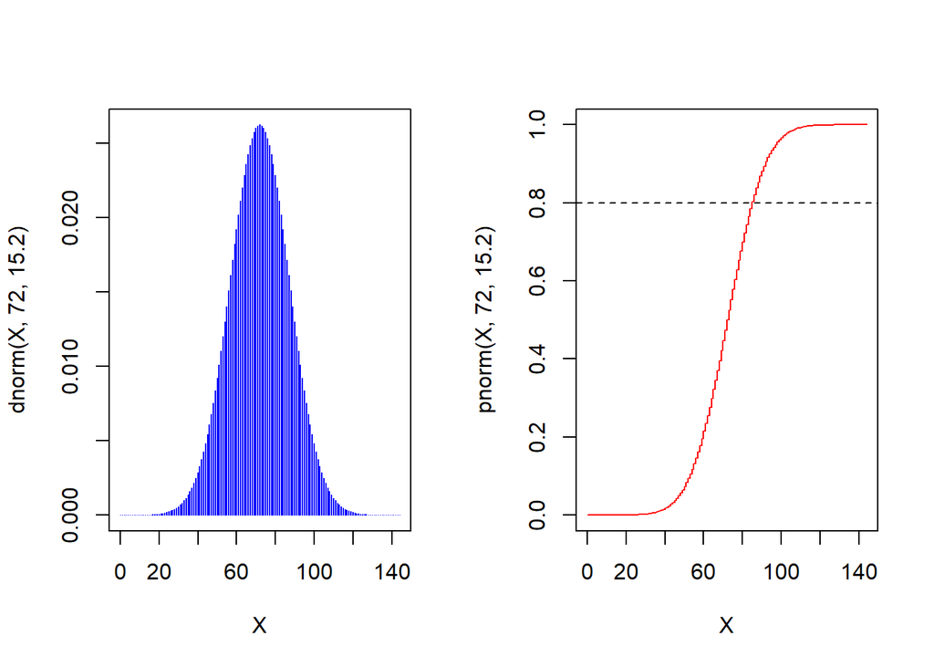

```r
X <- 0:144
par(mfrow=c(1,2))
plot(X, dnorm(X,72,15.2), type="h", col="blue")
plot(X, pnorm(X,72,15.2), type="s", col="red"); abline(h=0.8, lty=2)
```

# 4 Príklady na riešenie

V každej úlohe treba vykresliť aj grafy

## 4.1

Majme náhodnú premennú X, ktorá predstavuje počet pokazených kusov v sérii 500 novovyrobených televízorov. Vieme, že kazovosť prevádzky je 8 kusov na 1000 výrobkov. Aká je pravdepodobnosť, že v spomenutej sérii sa vyskytnú a) najviac 2, b) práve 3, c) aspoň 4 poruchové televízory?

## 4.2

Náhodná premenná X, ktorou je % chybných tehiel má normálne rozdelenie pravdepodobnosti so strednou hodnotou µ = 19 a disperziou σ2 = 9, teda X ∼ N(19,9). a) Vypočítajte pravdepodobnosť toho, že v dodávke tehiel ich bude viac ako 15 % a menej ako 25 % chybných. b) Za aké najnižšie percento chybných tehiel sa môžeme zaručiť s pravdepodobnosťou 0.95?

## 4.3

Šachový šampión Gary Kasparov vyhráva v priemere 99 turnajov zo 100. Aká je pravdepodobnosť, že prehrá, ak hrá simultánnu hru s 50 hráčmi, 10krát, 5krát, ani raz?

## 4.4

Automobilová firma vyrobila za mesiac 200 automobilov, z toho 10 s drobnopu chybou interiéru vozidla. Firma chce kúpiť 5 automobilov tejto značky. Aká je pravdepodobnosť, že: kúpime všetky autá bez chyby, najviac tri autá budú chybné?

## 4.5

Do reštaurácie príde v priemere 20 ľudí za hodinu, aká je pravdepodobnosť, že v priebehu 15 minút príde jeden človek, že v priebehu 5 minút nikto nepríde, v priebehu 10 minút príde aspoň 10 ľudí

## 4.6

Úspešnosť zásahu basketbalistu je 70 %. a) Nájdite rozdelenie pravdepodobnosti náhodnej premennej X, ktorou je počet úspešných zásahov pri 15 násobnom opakovaní pokusu. Vypočítajte strednú hodnotu a disperziu. b) S akou pravdepodobnosťou sa basketbalista trafí aspoň 11-krát? c) Koľkokrát musí trafiť, aby dosiahol 80 % úspešnosť? d) Nech pri tom istom basketbalistovi je náhodná premenná Y daná súčtom bodov, ktoré získa počas 15 hodov, ak za kôš získa 10 a za minutie koša stratí 5 bodov. Nájdite jej strednú hodnotu.

## 4.7

V sociologickom prieskume určitej populácie sa ukázalo, že počet rokov vzdelania má normálne rozdelenie so strednou hodnotou 13,2 roka a štandardnou odchýlkou 1.5 roka. Ak náhodne vyberieme osobu z tejto skupiny, aká je pravdepodobnosť, že jej vzdelanie má dĺžku v rozpätí od 13 do 14 rokov? Ak náhodne vyberieme osobu z tejto skupiny, aká je pravdepodobnosť, že má aspoň 13 rokov vzdelania? Zamestnávateľ chce stanoviť požiadavku na minimálny počet rokov vzdelania tak, aby ho spĺňalo 5% ľudí. Aká má byť táto hranica?

## 4.8

Čas, po ktorý určitý stroj pracuje, predtým než sa pokazí (čas medzi poruchami) má exponenciálne rozdelenie s parametrom λ=2. Čas sa meria v hodinách. Aká je pravdepodobnosť, že stroj bude nepretržite pracovať aspoň jednu hodinu? Za aký bezporuchový čas sa možno zaručiť s pravdepodobnosťou 0.9?

## 4.9

Príbalový leták vakcíny proti chrípke uvádza, že vo vzorke 100 000 ľudí, ktorí sa dajú zaočkovať, majú v priemere 2 ľudia alergické reakcie. Predpokladajme, že sa dalo zaočkovať 350 000 ľudí. Aká je pravdepodobnosť, že nikto nebude mať alergickú reakciu, práve 5 ľudí bude mať alergickú reakciu, aspoň 3 ľudia budú mať alergickú reakciu?